# Inference

```r
library(MASS)
library(tidyverse)
theme = theme_minimal()
```

# Experimental Analysis

Hypotheses:

H1a: The metaphorical conditions are more likely to have a higher mean donation than the literal condition.

H1b: There is a difference in mean donation given whether the metaphor was battle or journey.

- Note: this is unsupported by the observational work, but differences in behavior due to the metaphor family are worth testing.

H2: Consistent findings to Hendricks and Boroditsky 2016:

People who read the battle metaphor agreed more with the statement that the patient “will feel guilty if he does not recover,” than did people who read about the journey

People who read the journey metaphor agreed more with the statement that the patient “can make peace with his situation,” than the group who read the battle metaphor

Men, more than women, will say the patient will feel guilty

## Load clean data

Created via `clean_data.R`.

```r
sc = function(x) {
  return((x - mean(x, na.rm = T)) / (2 * sd(x, na.rm = T)))
}


df_cleaned = read_csv("data/clean_data.csv", col_types = cols()) %>%
              mutate(
              cond_sex = factor(cond_sex, levels = c("male", "female")),
              cond_metaphor = factor(cond_metaphor, levels = c("literal", "battle", "journey")),
              cond = paste(cond_sex, "_", cond_metaphor, sep=""),

              rt_trial = rt_trial / (1000 * 60), # convert to floating point minutes
              total_time = total_time / (1000 * 60), # convert to floating point minutes

              age.z = sc(age),
              exp_cancer = (self_cancer == "Y" | ff_cancer == "Y"),

              urgent = as.integer(urgent),
              sympathy = as.integer(sympathy),
              peace = as.integer(peace),
              guilty = as.integer(guilty),

              gender = factor(gender, levels = c("M", "F", "NB")),
              self_cancer = factor(self_cancer, levels = c("Y", "N")),
              ff_cancer = factor(ff_cancer, levels = c("Y", "N")),
              english = factor(english, levels = c("Y", "N")),
              socioeconomic = factor(socioeconomic, levels = c("<10k", "10-25k", "25-50k", "50-75k", "75-100k", "100-150k", ">150k")),
              education = factor(education, levels = c("<HS", "HS", "A", "B", "M", "P", "D")))
```

## Check over details of experiment

```r
length(unique(df_cleaned$ppt))
```

```
## [1] 200
```

```r
table(df_cleaned$gender)
```

```
##
##   M   F  NB
## 123  77   0
```

```r
table(df_cleaned$cond_metaphor)
```

```
##
## literal  battle journey
##      64      69      67
```

## Regression

### H1

// TODO: consider modeling socioeconomic status as an ordinal variable. Right now it’s categorical.

**Does simply having either metaphor family present explain donation behavior?**

```r
df_cleaned$cond_anymet = df_cleaned$cond_metaphor %in% c("battle", "journey")
```

```r
h1a.model = lm(donation ~ cond_sex + gender + education + socioeconomic + age.z + self_cancer + ff_cancer, data = df_cleaned)
h1a.model.full = lm(donation ~ cond_anymet + cond_sex + gender + education + socioeconomic + age.z + self_cancer + ff_cancer, data = df_cleaned)

summary(h1a.model.full)
```

```
##
## Call:
## lm(formula = donation ~ cond_anymet + cond_sex + gender + education +
##     socioeconomic + age.z + self_cancer + ff_cancer, data = df_cleaned)
##
## Residuals:
##     Min      1Q  Median      3Q     Max
## -21.083 -11.109  -5.601  11.413  37.559
##
## Coefficients:
##                        Estimate Std. Error t value Pr(>|t|)
## (Intercept)            31.40614   18.04844   1.740   0.0836 .
## cond_anymetTRUE         2.18858    2.43985   0.897   0.3709
## cond_sexfemale         -1.98759    2.37731  -0.836   0.4042
## genderF                 3.83466    2.42336   1.582   0.1153
## educationHS           -13.71365   16.15362  -0.849   0.3970
## educationA            -15.12275   16.19254  -0.934   0.3516
## educationB            -14.24099   16.15242  -0.882   0.3791
## educationM             -6.21391   16.44603  -0.378   0.7060
## educationP             -6.29713   17.76609  -0.354   0.7234
## socioeconomic10-25k    -2.11261    4.64129  -0.455   0.6495
## socioeconomic25-50k    -0.07373    4.12608  -0.018   0.9858
## socioeconomic50-75k    -2.50658    4.35151  -0.576   0.5653
## socioeconomic75-100k    3.25936    5.61305   0.581   0.5622
## socioeconomic100-150k  -6.87217    6.38218  -1.077   0.2830
## socioeconomic>150k     -0.46595    7.96946  -0.058   0.9534
## age.z                  -1.50313    2.47682  -0.607   0.5447
## self_cancerN           -3.15345    6.90989  -0.456   0.6487
## ff_cancerN             -2.95598    2.36085  -1.252   0.2122
## ---
## Signif. codes:  0 '***' 0.001 '**' 0.01 '*' 0.05 '.' 0.1 ' ' 1
##
## Residual standard error: 15.53 on 178 degrees of freedom
##   (4 observations deleted due to missingness)
## Multiple R-squared:  0.07538,    Adjusted R-squared:  -0.01292
## F-statistic: 0.8537 on 17 and 178 DF,  p-value: 0.6293
```

```r
anova(h1a.model, h1a.model.full, test = "Chisq")
```

```
## Analysis of Variance Table
##
## Model 1: donation ~ cond_sex + gender + education + socioeconomic + age.z +
##     self_cancer + ff_cancer
## Model 2: donation ~ cond_anymet + cond_sex + gender + education + socioeconomic +
##     age.z + self_cancer + ff_cancer
##   Res.Df   RSS Df Sum of Sq Pr(>Chi)
## 1    179 43147
## 2    178 42953  1    194.16   0.3697
```

**Does either the battle or the journey metaphor family explain donation behavior beyond the literal condition?**

To be compared with the similar analysis from the observational work.

```r
h1b.model = lm(donation ~ cond_sex + gender + education + socioeconomic + age.z + self_cancer + ff_cancer, data = df_cleaned)
h1b.model.full = lm(donation ~ cond_metaphor + cond_sex + gender + education + socioeconomic + age.z + self_cancer + ff_cancer, data = df_cleaned)

summary(h1b.model.full)
```

```
##
## Call:
## lm(formula = donation ~ cond_metaphor + cond_sex + gender + education +
##     socioeconomic + age.z + self_cancer + ff_cancer, data = df_cleaned)
##
## Residuals:
##     Min      1Q  Median      3Q     Max
## -21.223 -10.994  -5.455  11.545  37.722
##
## Coefficients:
##                        Estimate Std. Error t value Pr(>|t|)
## (Intercept)            31.47245   18.10337   1.738   0.0839 .
## cond_metaphorbattle     2.40309    2.82101   0.852   0.3954
## cond_metaphorjourney    1.97991    2.80218   0.707   0.4808
## cond_sexfemale         -1.94264    2.40196  -0.809   0.4197
## genderF                 3.82233    2.43138   1.572   0.1177
## educationHS           -13.85348   16.22397  -0.854   0.3943
## educationA            -15.27194   16.26650  -0.939   0.3491
## educationB            -14.39478   16.22818  -0.887   0.3763
## educationM             -6.41192   16.54222  -0.388   0.6988
## educationP             -6.39799   17.82727  -0.359   0.7201
## socioeconomic10-25k    -2.09776    4.65509  -0.451   0.6528
## socioeconomic25-50k    -0.06074    4.13832  -0.015   0.9883
## socioeconomic50-75k    -2.47150    4.36954  -0.566   0.5724
## socioeconomic75-100k    3.29003    5.63210   0.584   0.5599
## socioeconomic100-150k  -6.83971    6.40329  -1.068   0.2869
## socioeconomic>150k     -0.49575    7.99380  -0.062   0.9506
## age.z                  -1.47273    2.49160  -0.591   0.5552
## self_cancerN           -3.09800    6.93843  -0.446   0.6558
## ff_cancerN             -2.96957    2.36902  -1.253   0.2117
## ---
## Signif. codes:  0 '***' 0.001 '**' 0.01 '*' 0.05 '.' 0.1 ' ' 1
##
## Residual standard error: 15.58 on 177 degrees of freedom
##   (4 observations deleted due to missingness)
## Multiple R-squared:  0.07551,    Adjusted R-squared:  -0.01851
## F-statistic: 0.8031 on 18 and 177 DF,  p-value: 0.695
```

```r
anova(h1b.model, h1b.model.full, test = "Chisq")
```

```
## Analysis of Variance Table
##
## Model 1: donation ~ cond_sex + gender + education + socioeconomic + age.z +
##     self_cancer + ff_cancer
## Model 2: donation ~ cond_metaphor + cond_sex + gender + education + socioeconomic +
##     age.z + self_cancer + ff_cancer
##   Res.Df   RSS Df Sum of Sq Pr(>Chi)
## 1    179 43147
## 2    177 42947  2    199.83   0.6625
```

#### Visualization

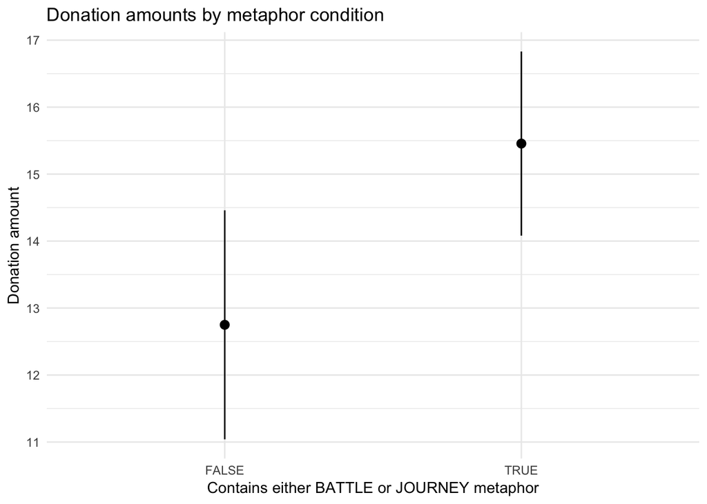

```r
df_cleaned %>%
  ggplot(aes(x = cond_anymet,
             y = donation)) +
  stat_summary (fun.y = function(x){mean(x)},
                fun.ymin = function(x){mean(x) - 1*sd(x)/sqrt(length(x))},
                fun.ymax = function(x){mean(x) + 1*sd(x)/sqrt(length(x))},
                geom= 'pointrange',
                position=position_dodge(width=0.95)) +
  labs(x = "Contains either BATTLE or JOURNEY metaphor",
       y = "Donation amount",
       title = "Donation amounts by metaphor condition") +
  theme_minimal()
```

### H2

Can we replicate Hendricks & Boroditsky?

Does the metaphorical and sex conditions have a relationship to participant’s rating of perceived guilt?

// A few things things: // 1) H+B (2018) look at cond_metaphor * gender. We probably should too. With maybe cond_sex being the new thing. // 2) H+B (2018) also don’t have a “literal” condition. So the pure replication is just looking at the battle/journey trials. Then we can look // at {battle, journey, literal} or {metaphor, no_metaphor}. // 3) H+B (2018) use a “difference” score instead of peace/guilt. // This is reflected in my changes below (I didn’t delete your stuff, just moved it to the bottom).

// This also means we should be checking comparisons for each of these variables.

```r
# Replicate H+B (2018) "difference" score: peace - guilt.

df_cleaned$diff = df_cleaned$peace - df_cleaned$guilty
df_just_metaphor = df_cleaned %>%
  filter(cond_metaphor != "literal")

model.reduced = lm(diff ~ cond_sex + gender + education + socioeconomic + self_cancer + ff_cancer,
                 data = df_just_metaphor)
model.just_met = lm(diff ~ cond_metaphor + cond_sex + gender + education + socioeconomic + self_cancer + ff_cancer,
                          data = df_just_metaphor)
model.ppt_gender_metaphor_interaction = lm(diff ~ cond_metaphor*gender + cond_sex + education + socioeconomic + self_cancer + ff_cancer,
                          data = df_just_metaphor)
model.patient_gender_metaphor_interaction = lm(diff ~ cond_metaphor*cond_sex + gender + education + socioeconomic + self_cancer + ff_cancer,
                      data = df_just_metaphor)
model.both_interactions = lm(diff ~ cond_metaphor*cond_sex + cond_metaphor*gender + education + socioeconomic + self_cancer + ff_cancer,
                      data = df_just_metaphor)

summary(model.both_interactions)
```

```
##
## Call:
## lm(formula = diff ~ cond_metaphor * cond_sex + cond_metaphor *
##     gender + education + socioeconomic + self_cancer + ff_cancer,
##     data = df_just_metaphor)
##
## Residuals:
##     Min      1Q  Median      3Q     Max
## -4.8184 -1.3406 -0.1961  1.5147  5.0131
##
## Coefficients:
##                                     Estimate Std. Error t value Pr(>|t|)
## (Intercept)                          3.78698    2.50646   1.511   0.1335
## cond_metaphorjourney                -0.27892    0.59662  -0.467   0.6410
## cond_sexfemale                      -0.46181    0.55598  -0.831   0.4079
## genderF                             -0.12543    0.56273  -0.223   0.8240
## educationHS                         -2.81042    2.24611  -1.251   0.2134
## educationA                          -2.24168    2.28226  -0.982   0.3280
## educationB                          -2.71327    2.24349  -1.209   0.2290
## educationM                          -3.47909    2.32407  -1.497   0.1371
## educationP                          -2.54497    2.59032  -0.982   0.3279
## socioeconomic10-25k                 -0.02526    0.76874  -0.033   0.9738
## socioeconomic25-50k                 -0.01382    0.67634  -0.020   0.9837
## socioeconomic50-75k                  0.85602    0.69385   1.234   0.2198
## socioeconomic75-100k                 1.71577    0.92940   1.846   0.0674 .
## socioeconomic100-150k                0.65706    1.09246   0.601   0.5487
## socioeconomic>150k                   0.60419    1.48573   0.407   0.6850
## self_cancerN                         0.20155    0.98705   0.204   0.8386
## ff_cancerN                          -0.50873    0.40976  -1.242   0.2169
## cond_metaphorjourney:cond_sexfemale  0.77745    0.77500   1.003   0.3179
## cond_metaphorjourney:genderF        -0.03866    0.81773  -0.047   0.9624
## ---
## Signif. codes:  0 '***' 0.001 '**' 0.01 '*' 0.05 '.' 0.1 ' ' 1
##
## Residual standard error: 2.134 on 116 degrees of freedom
##   (1 observation deleted due to missingness)
## Multiple R-squared:  0.111,  Adjusted R-squared:  -0.027
## F-statistic: 0.8043 on 18 and 116 DF,  p-value: 0.6918
```

```r
anova(model.reduced, model.just_met)
```

```
## Analysis of Variance Table
##
## Model 1: diff ~ cond_sex + gender + education + socioeconomic + self_cancer +
##     ff_cancer
## Model 2: diff ~ cond_metaphor + cond_sex + gender + education + socioeconomic +
##     self_cancer + ff_cancer
##   Res.Df    RSS Df Sum of Sq      F Pr(>F)
## 1    119 533.12
## 2    118 533.01  1   0.11447 0.0253 0.8738
```

```r
anova(model.just_met, model.ppt_gender_metaphor_interaction)
```

```
## Analysis of Variance Table
##
## Model 1: diff ~ cond_metaphor + cond_sex + gender + education + socioeconomic +
##     self_cancer + ff_cancer
## Model 2: diff ~ cond_metaphor * gender + cond_sex + education + socioeconomic +
##     self_cancer + ff_cancer
##   Res.Df    RSS Df  Sum of Sq     F Pr(>F)
## 1    118 533.01
## 2    117 533.01  1 0.00066106 1e-04 0.9904
```

```r
anova(model.just_met, model.patient_gender_metaphor_interaction)
```

```
## Analysis of Variance Table
##
## Model 1: diff ~ cond_metaphor + cond_sex + gender + education + socioeconomic +
##     self_cancer + ff_cancer
## Model 2: diff ~ cond_metaphor * cond_sex + gender + education + socioeconomic +
##     self_cancer + ff_cancer
##   Res.Df    RSS Df Sum of Sq      F Pr(>F)
## 1    118 533.01
## 2    117 528.43  1    4.5748 1.0129 0.3163
```

```r
anova(model.patient_gender_metaphor_interaction, model.both_interactions)
```

```
## Analysis of Variance Table
##
## Model 1: diff ~ cond_metaphor * cond_sex + gender + education + socioeconomic +
##     self_cancer + ff_cancer
## Model 2: diff ~ cond_metaphor * cond_sex + cond_metaphor * gender + education +
##     socioeconomic + self_cancer + ff_cancer
##   Res.Df    RSS Df Sum of Sq      F Pr(>F)
## 1    117 528.43
## 2    116 528.42  1  0.010183 0.0022 0.9624
```

```r
anova(model.both_interactions)
```

```
## Analysis of Variance Table
##
## Response: diff
##                         Df Sum Sq Mean Sq F value Pr(>F)
## cond_metaphor            1   1.29  1.2878  0.2827 0.5959
## cond_sex                 1   0.32  0.3165  0.0695 0.7926
## gender                   1   0.00  0.0008  0.0002 0.9893
## education                5  20.55  4.1092  0.9021 0.4824
## socioeconomic            6  30.90  5.1498  1.1305 0.3490
## self_cancer              1   0.01  0.0146  0.0032 0.9550
## ff_cancer                1   8.30  8.2983  1.8217 0.1797
## cond_metaphor:cond_sex   1   4.57  4.5748  1.0043 0.3184
## cond_metaphor:gender     1   0.01  0.0102  0.0022 0.9624
## Residuals              116 528.42  4.5554
```

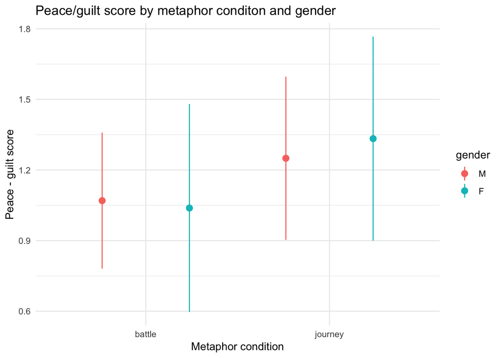

```r
df_just_metaphor %>%
  ggplot(aes(x = cond_metaphor,
             y = diff,
             color = gender)) +
  stat_summary (fun.y = function(x){mean(x)},
                fun.ymin = function(x){mean(x) - 1*sd(x)/sqrt(length(x))},
                fun.ymax = function(x){mean(x) + 1*sd(x)/sqrt(length(x))},
                geom= 'pointrange',
                position=position_dodge(width=0.95)) +
  labs(x = "Metaphor condition",
       y = "Peace - guilt score",
       title = "Peace/guilt score by metaphor conditon and gender") +
  theme_minimal()
```